# INTRODUCTION

In the modern age of technology, new standards of surveillance and accountability are being held. In particular, Buzzfeed released the “FinCEN” files in 2020. The FinCEN files are a compilation of 2,500 documents that banks sent to U.S authorities between 2000-2017 highlighting client activities. Banks use these reports to report suspicious behavior, but they are not proof of wrongdoing or crime. This leak of information revealed illegal activities such as JP Morgan allowed a company to move for more than $1 billion through a London account owned by a mobster on the FBI’s 10 Most Wanted List, Vladimir Putin used Barclay’s bank in London to avoid sanctions, and the United Arab Emirates’ central bank failed to act on warnings about a local firm who was helping Iran evade sanctions. The International Consortium of Investigative Journalists (ICIJ), together with BuzzFeed News and 108 other media partners in 88 countries, spent 16 months organizing and analyzing the documents.

During the analysis, Group 6 focused on an analysis of categorical and numerical variables. Firstly, we identified the bank that reported the suspicious activity, where exactly the bank transactions started from as well as where it ended up, calculated the length or time of the transaction from the beginning to the end date, and took a note of the monetary value of each transaction in US dollars. We also took into consideration the number of transactions that each beneficiary / originator Bank conducted. After Group 6’s exploratory data analysis, we focused on two specific questions that we thought highlighted our most interesting findings. We decided to see if there was a way to predict the beneficiary country by identifying the originator country as well as the number of transactions they made. We also wanted to highlight the relationship between the number of banks involved in a country, its GDP, its haven score, its global scale weight and the average or mean transacted amount.

Group 6’s first predictive question asked if the relationship between the number of transactions in the originator country be used to predict the beneficiary country. This data has the potential to determine relationships between countries. In addition, our second predictive question is between the number of banks involved in a country, its GDP, its haven score, its global scale weight and the average or mean transacted amount. . From this question, we are expecting that countries with a positive correlation between the response variables and the predictor variable.

# DATA

Originally, the documents came from over 2000 suspicious activity reports , otherwise known as SARs. These were filed by FinCEN and were later published by Buzzfeed News. The ICIJ later released these reports with Buzzfeed News, after taking 16 months to compile. These became known as the FinCEN files. This current subset contains more than 18153 transactions extracted from the FinCEN files. These files were open to the public and many well known banks like Barclays Bank were exposed of their corrupt actions.

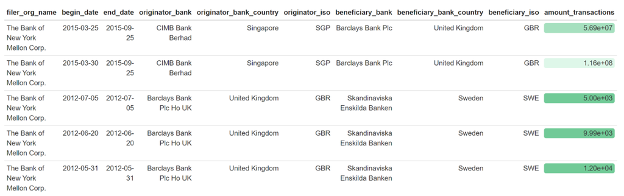

Upon looking at the dataset, there were many variables that seemed to prove most effective when analyzing the data. Firstly, the filer, or entity that filed the complaint was recorded. Each entry was an individual case of a suspicious transaction that was filed and/or complained. Another variable reported was the length of the transaction based off of the begin and end date. Other variables such as the beneficiary and originator country were recorded to see where trends occurred based on the location of the transaction. Lastly, the transaction amount or value was taken into account to consider where the largest transactions were from.

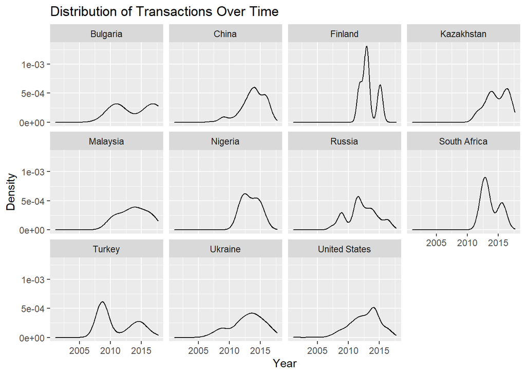

# RESULTS

## Question 1: What is the relationship between originator countries and beneficiary countries? (Partially written and coded by Vidhi Patel)

During our exploratory data analysis, we started by comparing the countries who most frequently took on the beneficiary bank role in a transaction and the countries who most frequently took on the originator bank role in a transaction. To do this, we created two bar graphs. Upon comparing the bar graphs we found that there was some correlation between the frequency of a certain country being a beneficiary versus an originator country. For example, in 4 out of the 5 top beneficiary and originator countries were the same. Therefore, we can say with some confidence that the probability of, for example Latvia, being a beneficiary country is a lot higher than the US, but a precise prediction cannot be extrapolated from just these two visuals.

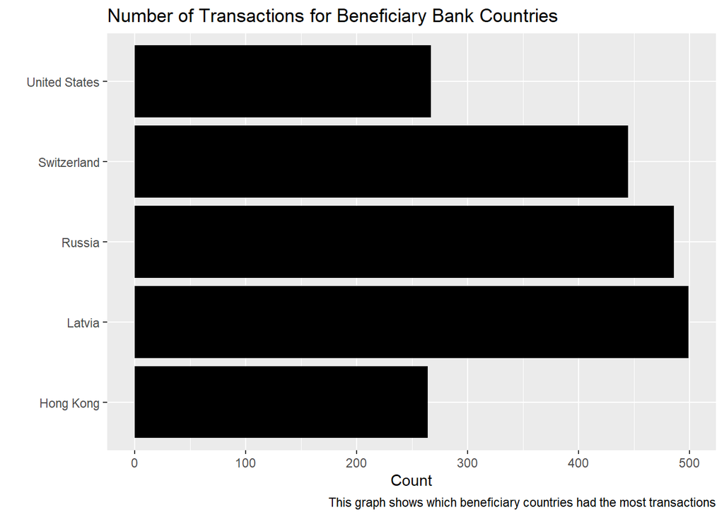

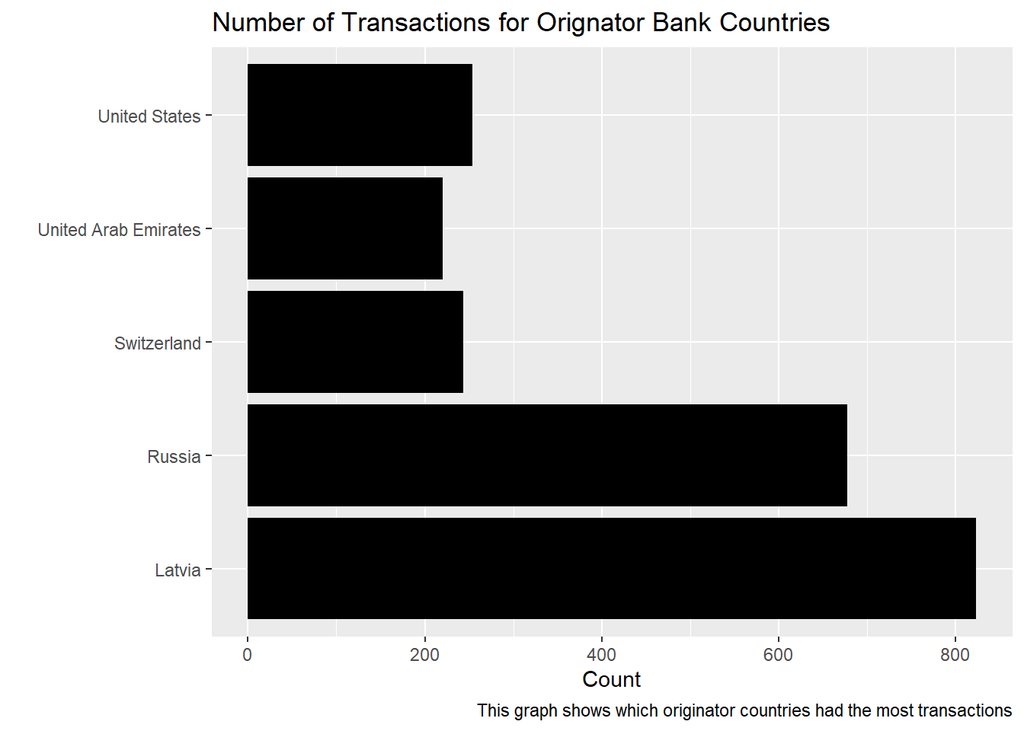

After obtaining these results, we had an additional question: does the number of beneficiaries and/or originators in a country correlate to the mean transacted amount of that country? Because of the similarity between the frequency of a certain country being a beneficiary versus an originator country, we ultimately chose to only focus on the beneficiary countries for this question. We visualized this relationship between the average transaction amount and the number of beneficiaries in a country by creating a scatter plot. The resulting graph however did not show a clear relationship. We were expecting that countries with a greater number of beneficiaries would have had a larger average transaction, but that wasn’t always the case. There were several countries where the average transaction amount was relatively High despite a low number of beneficiaries, as well as the contrary. This led us to conclude that there were likely other variables that were influencing transaction amounts.

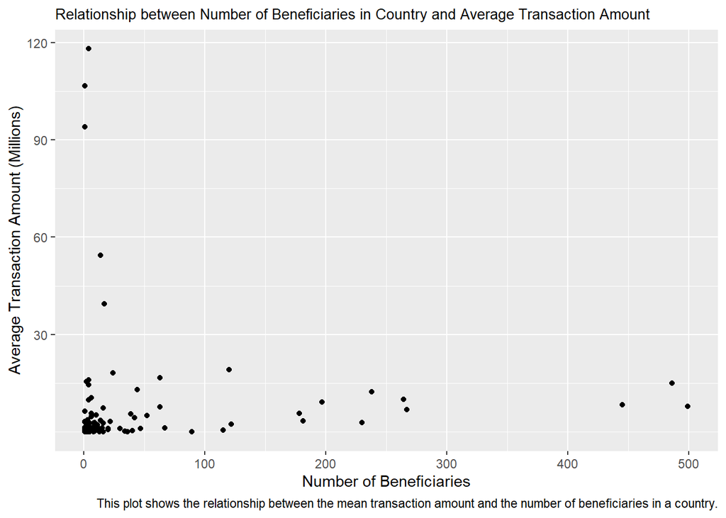

## Question 2: Is the average transaction amount in a country correlated to its GDP, total number of involved banks, personal remittances (received), its haven score and/or global scale weight? (Written and Coded by Vidhi Patel)

Following the results during EDA, we were curious to explore what variables were influencing transaction amounts. To do so, we decided to model the average transaction amount in a country using the country’s GDP, total number of banks involved, personal remittances (received) and/or the state of its tax and financial systems (as measured through haven score and global scale weight). Before any modeling was done, we predicted that the mean transaction amount would be positively correlated with each of the predictor variables. We sourced GDP and personal remittances data from the World Development Indicator package in R. We posed that countries with higher GDPs may have higher cash outflow resulting in a larger number of beneficiary transactions and ultimately drive up the total number of transactions. We also chose to include data on personal remittances received ($ US). Personal remittances are indicative of the monetary amount of all cash transfers that were to/from resident households as well as compensation given to nonresidents in the country. In general, these are very important sources of income in developing countries as migrants often send parts of their paycheck back home. In the context of our dataset, we thought this might be an important predictor as remittances can also be used to launder money from illegal activities according to the US Government Accountability Office (https://www.gao.gov/assets/gao-16-65.pdf). Values from 2011 were used for both GDP and Personal remittances. We also used two additional indicators on each country’s tax and financial systems which were obtained through the Tax Justice Network (https://cthi.taxjustice.net/en/#:~:text=Jurisdictions%20are%20ranked%20by%20their,Score%20and%20Global%20Scale%20Weight.) . The first indicator was the haven score which measures the scope for corporate tax abuse that the tax and financial systems allow in each country, with 0 being the minimum and 100 being the maximum. The second indicator was the global scale weight which measures the percent of financial activity conducted by multinational corporations that occurs in the country. These two indicators were of interest to us when modeling because we hypothesized that suspicious banking activity is more likely in countries with weaker tax and financial systems. Additionally, countries with a higher amount of financial activity from multinational corporations would likely have larger transaction amounts recorded. Values from 2021 were used for the haven score and global scale weight. Lastly, we derived the total number of transactions by adding the number of originator and beneficiary banks that were present in each country from the original FINCEN dataset. After grouping the predictor and response variables by country, we then proceeded to develop 10 different linear models. Although the FINCEN dataset had 119 countries, because of the availability of data for various predictor variables our modeling data only had 45 data points.

In our initial models, we chose to include variables without any log transformations. However, after conducting two-fold model selection through cross-validation and test/train data splitting and plotting the predicted vs actual data, we realized that our predictor and at least one of our explanatory variables needed to be log transformed. After doing this, our 10 models were as follows:

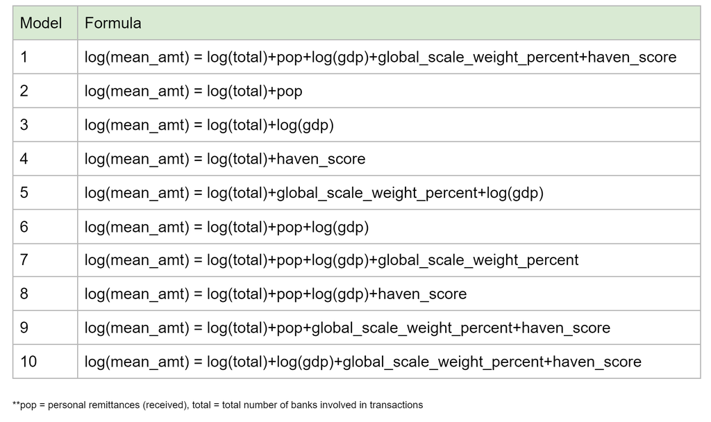

To find the most robust model, we compared the mean absolute error (MAE) and the root mean squared error (RMSE) of each model. To find the MAE, we split the data into training (80%) and testing (20%) sets and calculated the MAE in the testing dataset for each model. To find the RMSE, we performed 10-fold cross-validation and calculated the RMSE for each model. The three lowest MAE values and RMSE values had Model 2 (RMSE = 1.460; MAE = 2.143) and Model 5 (RMSE = 1.361; MAE = 2.126) in common. Because the MAE and RMSE for Model 5 was lower than Model 2, we chose to use Model 5 as our final model. After applying Model 5 to the dataset, we went on to visualize the fitted vs actual values as well as the residuals vs predictor variables. Based on the fitted vs actual values, we found that the model was weakly good at predicting the mean amount. While there was some correlation between the fitted and actual values, there were predictive issues at lower values. Additionally, our residual plots showed that the global scale weight percent was not randomly distributed along the horizontal axis. This likely means that a nonlinear model might have been better at predicting the mean transaction amount.

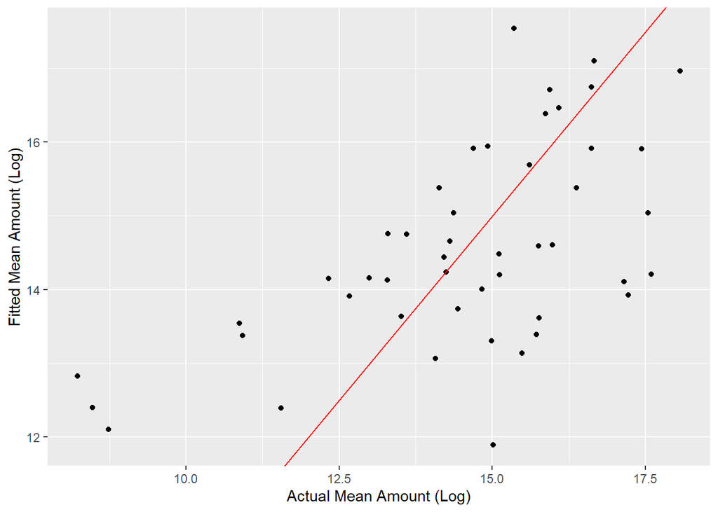

After applying Model 5 to the dataset, we went on to visualize the fitted vs actual values as well as the residuals vs predictor variables. Based on the fitted vs actual values, we found that the model was weakly good at predicting the mean amount. While there was some correlation between the fitted and actual values, there were predictive issues at lower values. Additionally, our residual plots showed that the global scale weight percent was not randomly distributed along the horizontal axis. This likely means that a nonlinear model might have been better at predicting the mean transaction amount.

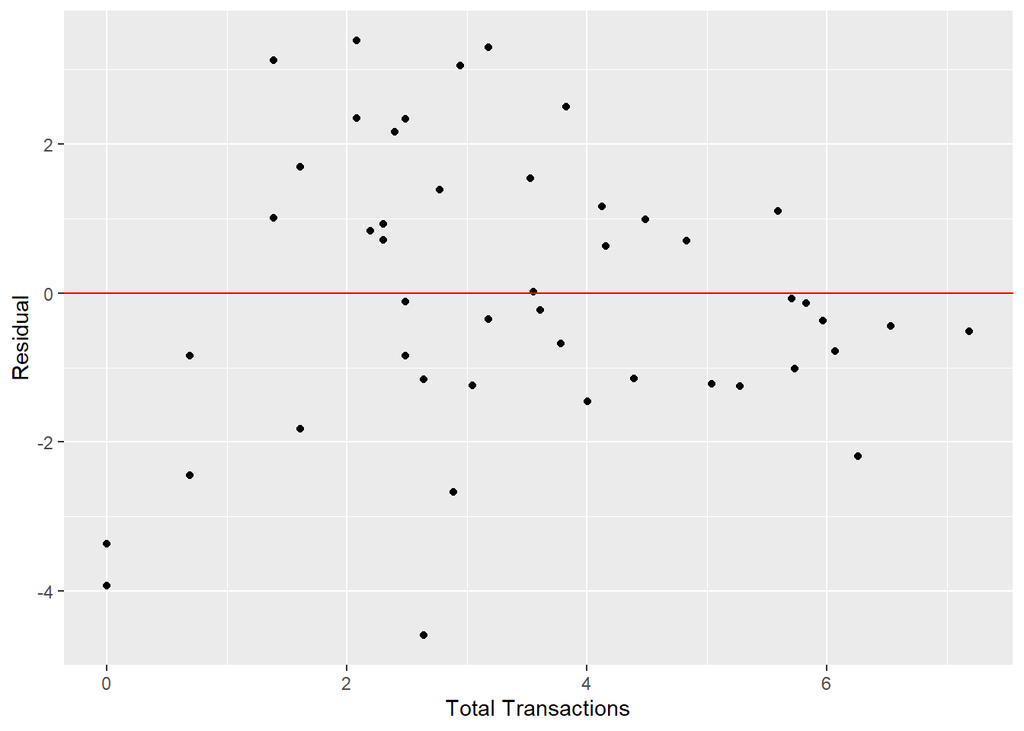

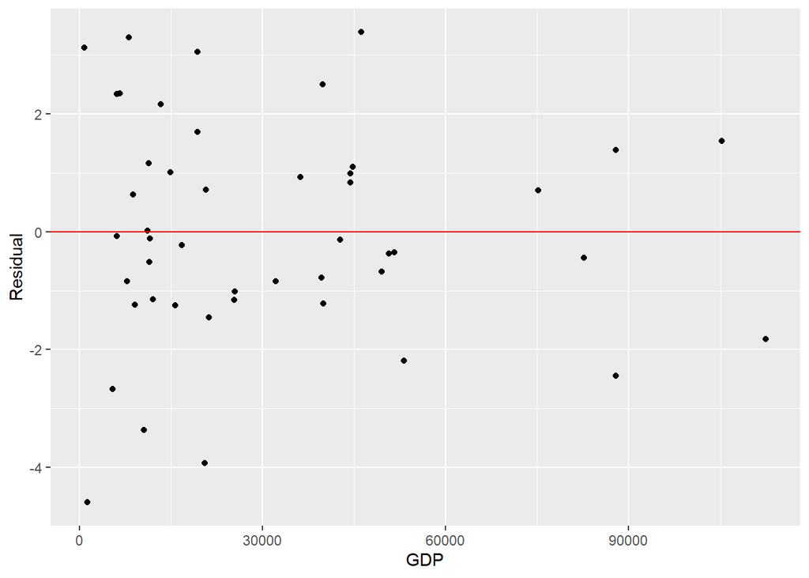

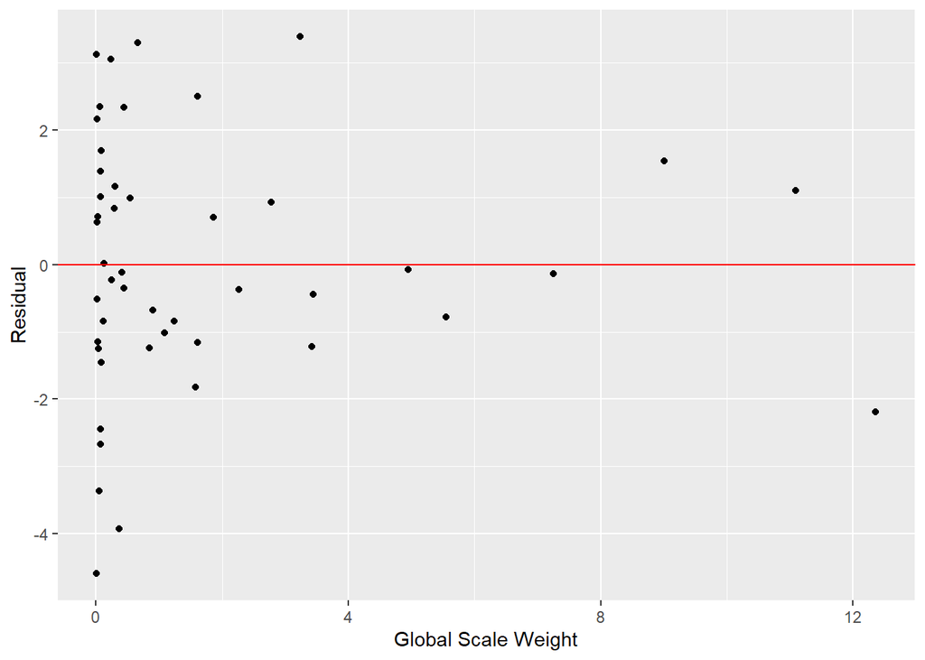

# CONCLUSION

Utilizing our findings, we are able to reach reasonable conclusions to our two predictive questions. The first predictive question suggests that the relationship between the number of transactions in the originator country is capable of predicting the beneficiary country. Through our use of two bar graphs we determined that we cannot definitively state that the relationship between the number of transactions in the originator country is a good predictor for the beneficiary country. We also decided to visualize this relationship between the average transaction amount and the number of beneficiaries in a country by creating a regression graph to see how strong their relationship was. The resulting graph did not show a clear relationship. Our initial hypothesis expected that countries with a greater number of beneficiaries would have had a larger average transaction; however, that was not the case consistently.

For our second question, our model was `log(mean transaction amount) = log(GDP) + Global Weight Score + log(total number of banks)`. Our initial hypothesis was correct in that each variable is positively correlated to mean transaction amount, the final model did not include all variables. Specifically, the haven score and personal remittance amounts were not included. While the model was somewhat successful, trying nonlinear models could help improve prediction. Furthermore, the dataset was quite small, adding more countries or using other relevant indicators from other sources might help improve the efficacy of the model. Using other statistical methods such as ANOVA or r-squared comparisons could also help build a more robust model.

All in all, our analysis attempts to present some details behind suspicious bank transactions around the world. As with most illegal activities, data is hard to come by but we hope that this analysis provides a glimpse into the world of suspicious transactions.